# Group Work Project #1 — Data Collection & Exploration

## Forecasting Crude Oil Prices with Probabilistic Graphical Models

**MScFE 660 Risk Management — WorldQuant University**

This notebook accompanies the GWP1 report. It (1) collects the macroeconomic, industry, financial and geopolitical drivers of the crude-oil price, (2) applies a three-stage cleaning protocol, and (3) runs the exploratory data analysis that grounds the stylized-fact discussion (report Step 8).

> **Data note.** Set `USE_LIVE = True` to pull the real series from FRED and Yahoo Finance — that is the data used for the final submission. When run without internet (`USE_LIVE = False`) the notebook regenerates a *reproducible synthetic panel* whose statistical fingerprint reproduces oil's documented stylized facts, so the pipeline and every figure run end-to-end. Synthetic output is labelled as such and must be replaced by the live pull before submission.

### 1 · Setup

```python
import json, io, warnings
import numpy as np
import pandas as pd
import matplotlib.pyplot as plt
import seaborn as sns
from scipy import stats
from statsmodels.tsa.stattools import adfuller, acf
from statsmodels.stats.diagnostic import acorr_ljungbox

warnings.filterwarnings("ignore")
sns.set_theme(style="whitegrid", context="notebook")
pd.set_option("display.width", 120)

USE_LIVE = False          # <-- True to download the real FRED/Yahoo series
SEED     = 20240628
START, END = "2005-01-07", "2024-05-31"
TARGET   = "WTI"
print("USE_LIVE =", USE_LIVE)
```

```
USE_LIVE = False
```

### 2 · Data dictionary

Variables are grouped following Alvi (2018): **macroeconomic / geopolitical**, **microeconomic (industry)** and **financial**. All series are aligned to a weekly (Friday) grid over 2005–2024.

```python
FRED = {   # series id, group, unit, native frequency
 "WTI":("DCOILWTICO","target","USD/bbl","daily"),
 "Brent":("DCOILBRENTEU","target","USD/bbl","daily"),
 "USD_Index":("DTWEXBGS","macro","index","daily"),
 "UST10Y":("DGS10","macro","%","daily"),
 "CPI":("CPIAUCSL","macro","index","monthly"),
 "IndProd":("INDPRO","macro","index","monthly"),
 "US_Production":("MCRFPUS2","micro","kbbl/d","monthly"),
 "US_Inventory":("WCESTUS1","micro","kbbl","weekly"),
 "SP500":("SP500","financial","index","daily"),
 "Gold":("GOLDPMGBD228NLBM","financial","USD/oz","daily"),
 "VIX":("VIXCLS","financial","index","daily"),
 "OVX":("OVXCLS","financial","index","daily"),
 "NatGas":("DHHNGSP","financial","USD/MMBtu","daily"),
}
YF = {"XLE":("XLE","financial","USD","daily")}   # energy-sector ETF (Yahoo)
# Geopolitical Risk index (GPR): Caldara & Iacoviello, matteoiacoviello.com
dd = pd.DataFrame(
    [(k,)+v for k,v in {**FRED, **YF}.items()],
    columns=["variable","source_id","group","unit","native_freq"]
).set_index("variable")
dd.loc["GPR"] = ["GPR (C&I)","geopolitical","index","monthly"]
dd
```

| variable | source_id | group | unit | native_freq |
| --- | --- | --- | --- | --- |
| WTI | DCOILWTICO | target | USD/bbl | daily |
| Brent | DCOILBRENTEU | target | USD/bbl | daily |
| USD_Index | DTWEXBGS | macro | index | daily |
| UST10Y | DGS10 | macro | % | daily |
| CPI | CPIAUCSL | macro | index | monthly |
| IndProd | INDPRO | macro | index | monthly |
| US_Production | MCRFPUS2 | micro | kbbl/d | monthly |
| US_Inventory | WCESTUS1 | micro | kbbl | weekly |
| SP500 | SP500 | financial | index | daily |
| Gold | GOLDPMGBD228NLBM | financial | USD/oz | daily |
| VIX | VIXCLS | financial | index | daily |
| OVX | OVXCLS | financial | index | daily |
| NatGas | DHHNGSP | financial | USD/MMBtu | daily |
| XLE | XLE | financial | USD | daily |
| GPR | GPR (C&I) | geopolitical | index | monthly |

### 3 · Data collection

**Live path** (submission) and **synthetic fallback** (offline).

```python
def fetch_live():
    """Download real series from FRED (CSV endpoint) + Yahoo (yfinance)."""
    import requests, yfinance as yf
    frames = []
    for name,(code_,*_ ) in FRED.items():
        url = f"https://fred.stlouisfed.org/graph/fredgraph.csv?id={code_}"
        txt = requests.get(url, timeout=30, headers={"User-Agent":"Mozilla/5.0"}).text
        s = pd.read_csv(io.StringIO(txt), index_col=0, parse_dates=True)
        s.columns=[name]; s[name]=pd.to_numeric(s[name], errors="coerce")
        frames.append(s)
    for name,(tick,*_ ) in YF.items():
        px = yf.download(tick, start=START, end=END, progress=False)["Close"]
        px.name=name; frames.append(px.to_frame())
    df = pd.concat(frames, axis=1).sort_index().resample("W-FRI").last().loc[START:END]
    return df
```

```python
def simulate():
    """Weekly panel reproducing oil stylized facts (SV + jumps + crisis regimes)."""
    rng = np.random.default_rng(SEED)
    idx = pd.date_range(START, END, freq="W-FRI"); n=len(idx); t=np.arange(n)
    risk=np.zeros(n)
    for i in range(1,n): risk[i]=0.96*risk[i-1]+rng.normal(0,1.0)
    def win(a,b): return (idx>=a)&(idx<=b)
    crises={ "GFC":(win("2008-07-01","2009-03-31"),-6.0),
             "Shale":(win("2014-07-01","2016-02-28"),-3.5),
             "COVID":(win("2020-02-20","2020-05-15"),-9.0),
             "Ukraine":(win("2022-02-20","2022-06-30"),+5.0)}
    shock=np.zeros(n)
    for m,mag in crises.values(): shock[m]+=mag
    vol=np.zeros(n); vol[0]=0.04; ret=np.zeros(n)
    for i in range(1,n):
        vol[i]=min(np.sqrt(0.00003+0.09*ret[i-1]**2+0.86*vol[i-1]**2),0.12)
        drift=0.0006-0.0009*(risk[i]>1.5); jump=0.0
        if rng.random()<0.025:
            jump=rng.normal(-0.035,0.09) if rng.random()<0.60 else rng.normal(0.025,0.06)
        core=np.clip(rng.standard_t(df=5)/np.sqrt(5/3),-6,6)
        ret[i]=drift+vol[i]*core+0.010*(shock[i]/9.0)+jump
    ret[risk>2.5]-=0.01
    ret=ret-np.mean(ret)+0.0007                     # realistic long-run drift
    wti=np.clip(45.0*np.exp(np.cumsum(ret)),5,None)
    brent=wti*(1.03+0.02*np.sin(t/25)+rng.normal(0,0.01,n))
    usd=100*np.exp(np.cumsum(-0.18*ret+0.02*(risk/10)+rng.normal(0,0.013,n)))
    ust10=np.clip(3.0-0.04*np.cumsum(rng.normal(0,0.05,n))-0.15*(risk/10),0.3,6.0)
    spr=0.0012+0.20*ret+0.004*(shock/9)+rng.normal(0,0.02,n); sp500=1200*np.exp(np.cumsum(spr))
    gold=450*np.exp(np.cumsum(0.0011-0.05*spr+0.02*(risk/10)+rng.normal(0,0.012,n)))
    vix=np.clip(17-6*(spr/0.02)+3*np.abs(risk),9,85)
    ovx=np.clip(30+220*np.abs(ret)+2.0*np.abs(risk),12,190)
    xle=40*np.exp(np.cumsum(0.0004+0.55*ret+rng.normal(0,0.015,n)))
    natgas=np.clip(6*np.exp(np.cumsum(rng.normal(0,0.05,n))),1.3,14)
    months=idx.to_period("M")
    cpi=190*np.exp(0.0004*t)*(1+rng.normal(0,0.001,n))
    indprod=95+0.02*t+4*np.sin(t/26)-0.3*np.abs(shock)
    prod=5.0+0.006*t+1.2*(t>470)+rng.normal(0,0.05,n)
    inv=350+25*np.sin(t/26+1)+np.cumsum(rng.normal(0,0.8,n))*0.3
    gpr=100+20*np.abs(rng.normal(0,1,n))
    for m,_ in crises.values(): gpr[m]+=rng.uniform(40,120,m.sum())
    df=pd.DataFrame({"WTI":wti,"Brent":brent,"USD_Index":usd,"UST10Y":ust10,"CPI":cpi,
        "IndProd":indprod,"US_Production":prod,"US_Inventory":inv,"SP500":sp500,
        "Gold":gold,"VIX":vix,"OVX":ovx,"NatGas":natgas,"XLE":xle,"GPR":gpr},index=idx)
    df.index.name="Date"
    # inject data-quality problems for the cleaning step -----------------------
    for c in ["CPI","IndProd","US_Production"]:
        keep=df.index.to_series().groupby(months).transform("first")==df.index.to_series()
        df.loc[~keep.values,c]=np.nan
    for c in ["Brent","NatGas","Gold","UST10Y"]:
        df.loc[rng.random(n)<0.015,c]=np.nan
    df.iloc[300,df.columns.get_loc("WTI")]*=10       # 10x fat-finger
    df.iloc[620,df.columns.get_loc("USD_Index")]=0.0 # impossible zero
    df.iloc[800,df.columns.get_loc("Gold")]=-5.0     # impossible negative
    return df

raw = fetch_live() if USE_LIVE else simulate()
print(("LIVE" if USE_LIVE else "SYNTHETIC"), "panel:", raw.shape)
raw.tail(3)
```

```
SYNTHETIC panel: (1013, 15)
```

| Date | WTI | Brent | USD_Index | UST10Y | CPI | IndProd | US_Production | US_Inventory | SP500 | Gold | VIX | OVX | NatGas | XLE | GPR |
| --- | --- | --- | --- | --- | --- | --- | --- | --- | --- | --- | --- | --- | --- | --- | --- |
| 2024-05-17 | 94.868439 | 99.202576 | 747.609844 | 3.121424 | NaN | NaN | NaN | 366.824816 | 4325.038353 | 6692.409558 | 11.170189 | 39.010800 | 5.448424 | 40.835206 | 106.235901 |
| 2024-05-24 | 93.390522 | 96.178496 | 751.917703 | 3.144847 | NaN | NaN | NaN | 366.036209 | 4272.422570 | 6744.981861 | 31.785327 | 40.863153 | 5.449198 | 39.967312 | 112.800874 |
| 2024-05-31 | 91.447267 | 95.677051 | 758.700007 | 3.136926 | NaN | NaN | NaN | 365.429692 | 4340.649379 | 6586.206665 | 21.724482 | 40.944266 | 5.305295 | 40.191228 | 110.189004 |

### 4 · Cleaning — three-stage protocol

Following report Step 5 the cleaning is split by responsibility:

- **Bad data** — impossible values (non-positive prices/indices) → `NaN`; duplicate timestamps dropped.
- **Extreme outliers** — a modified (MAD-based) z-score on log-returns flags fat-finger prints (`|z| > 8`).
- **Missing values** — monthly macro series carried forward (release-date logic); market gaps interpolated in time.

Every action is written to an auditable cleaning log (report Step 6).

```python
def clean(df):
    log=[]
    price_like=["WTI","Brent","USD_Index","CPI","IndProd","US_Production",
                "US_Inventory","SP500","Gold","NatGas","XLE","GPR"]
    for c in price_like:                              # --- bad data ---
        bad=df[c]<=0
        if bad.any():
            log.append(f"[bad-data] {c}: {int(bad.sum())} non-positive -> NaN "
                       f"{list(df.index[bad].date.astype(str))}")
            df.loc[bad,c]=np.nan
    d=df.index.duplicated().sum()
    if d: log.append(f"[bad-data] dropped {d} duplicate row(s)"); df=df[~df.index.duplicated()]
    for c in ["WTI","Brent","SP500","Gold","XLE","NatGas"]:   # --- outliers ---
        r=np.log(df[c]).diff(); med,mad=r.median(),(r-r.median()).abs().median()
        rz=0.6745*(r-med)/(mad if mad else np.nan); ext=rz.abs()>8
        if ext.any():
            log.append(f"[outlier] {c}: {int(ext.sum())} print(s) |robust z|>8 "
                       f"{list(df.index[ext].date.astype(str))}"); df.loc[ext,c]=np.nan
    for c in ["CPI","IndProd","US_Production"]:               # --- missing ---
        m=int(df[c].isna().sum()); df[c]=df[c].ffill().bfill()
        log.append(f"[missing] {c}: {m} gaps carried forward (release-date)")
    for c in ["Brent","NatGas","Gold","UST10Y","US_Inventory","WTI","SP500","XLE","USD_Index"]:
        m=int(df[c].isna().sum())
        if m: df[c]=df[c].interpolate(method="time").ffill().bfill()
        if m: log.append(f"[missing] {c}: {m} gap(s) time-interpolated")
    assert df.isna().sum().sum()==0
    return df, log

clean_df, cleaning_log = clean(raw.copy())
print("\n".join(cleaning_log))
```

```
[bad-data] USD_Index: 1 non-positive -> NaN [np.str_('2016-11-25')]
[bad-data] Gold: 1 non-positive -> NaN [np.str_('2020-05-08')]
[outlier] WTI: 5 print(s) |robust z|>8 [np.str_('2007-03-02'), np.str_('2007-05-25'), np.str_('2010-10-08'), np.str_('2010-10-15'), np.str_('2020-05-15')]
[outlier] Brent: 1 print(s) |robust z|>8 [np.str_('2007-05-25')]
[missing] CPI: 780 gaps carried forward (release-date)
[missing] IndProd: 780 gaps carried forward (release-date)
[missing] US_Production: 780 gaps carried forward (release-date)
[missing] Brent: 15 gap(s) time-interpolated
[missing] NatGas: 19 gap(s) time-interpolated
[missing] Gold: 16 gap(s) time-interpolated
[missing] UST10Y: 13 gap(s) time-interpolated
[missing] WTI: 5 gap(s) time-interpolated
[missing] USD_Index: 1 gap(s) time-interpolated
```

### 5 · Stylized-fact statistics (report Step 8)

```python
r = np.log(clean_df[TARGET]).diff().dropna()
jb  = stats.jarque_bera(r)
adf_l = adfuller(clean_df[TARGET], autolag="AIC")
adf_r = adfuller(r, autolag="AIC")
lb_r  = acorr_ljungbox(r,   lags=[10], return_df=True)["lb_pvalue"].iloc[0]
lb_r2 = acorr_ljungbox(r**2,lags=[10], return_df=True)["lb_pvalue"].iloc[0]
summary = pd.Series({
 "n_returns":r.size,
 "mean weekly return":r.mean(),
 "annualised vol":r.std()*np.sqrt(52),
 "skewness":stats.skew(r),
 "excess kurtosis":stats.kurtosis(r),
 "Jarque-Bera p":jb.pvalue,
 "ADF level p (price)":adf_l[1],
 "ADF p (returns)":adf_r[1],
 "Ljung-Box p, returns":lb_r,
 "Ljung-Box p, squared returns":lb_r2,
 "corr(WTI,USD)":clean_df.WTI.pct_change().corr(clean_df.USD_Index.pct_change()),
 "corr(WTI,SP500)":clean_df.WTI.pct_change().corr(clean_df.SP500.pct_change()),
 "corr(WTI,XLE)":clean_df.WTI.pct_change().corr(clean_df.XLE.pct_change()),
})
summary.round(4)
```

```
n_returns                       1012.0000
mean weekly return                 0.0007
annualised vol                     0.2727
skewness                          -0.0514
excess kurtosis                    4.6473
Jarque-Bera p                      0.0000
ADF level p (price)                0.3605
ADF p (returns)                    0.0000
Ljung-Box p, returns               0.0011
Ljung-Box p, squared returns       0.0000
corr(WTI,USD)                     -0.4291
corr(WTI,SP500)                    0.3422
corr(WTI,XLE)                      0.8089
dtype: float64
```

### 6 · Exploratory plots

**(A) Distributional** — return distribution vs Normal + Q-Q.

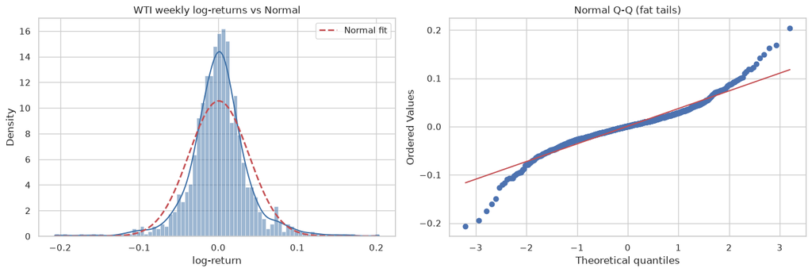

```python
fig,ax=plt.subplots(1,2,figsize=(14,4.8))
sns.histplot(r,bins=80,stat="density",kde=True,ax=ax[0],color="#3b6ea5")
x=np.linspace(r.min(),r.max(),400)
ax[0].plot(x,stats.norm.pdf(x,r.mean(),r.std()),"r--",lw=2,label="Normal fit")
ax[0].set(title="WTI weekly log-returns vs Normal",xlabel="log-return"); ax[0].legend()
stats.probplot(r,dist="norm",plot=ax[1]); ax[1].set_title("Normal Q-Q (fat tails)")
plt.tight_layout(); plt.show()
```

**(B) Time series** — price with events, returns, rolling volatility.

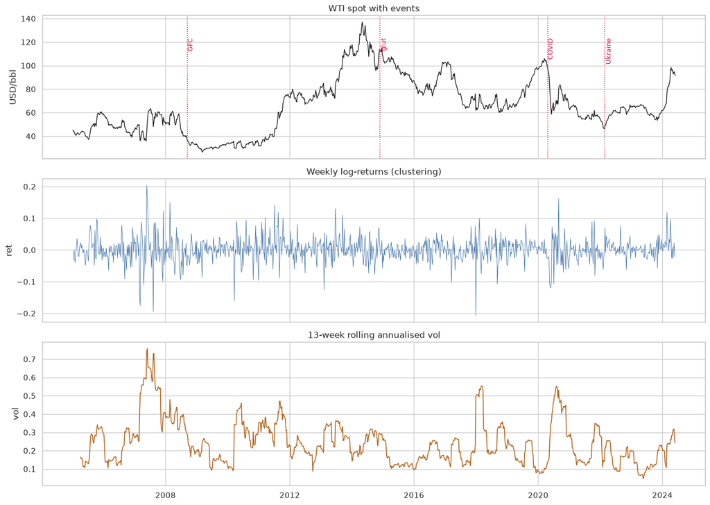

```python
fig,ax=plt.subplots(3,1,figsize=(14,10),sharex=True)
ax[0].plot(clean_df.index,clean_df[TARGET],color="#1a1a1a",lw=1)
ax[0].set(title="WTI spot with events",ylabel="USD/bbl")
for d,l in [("2008-09-15","GFC"),("2014-11-27","glut"),("2020-04-20","COVID"),("2022-02-24","Ukraine")]:
    ax[0].axvline(pd.Timestamp(d),color="crimson",ls=":",lw=1.1)
    ax[0].text(pd.Timestamp(d),clean_df[TARGET].max()*.9,l,rotation=90,color="crimson",va="top",fontsize=9)
ax[1].plot(r.index,r,color="#3b6ea5",lw=.6); ax[1].set(title="Weekly log-returns (clustering)",ylabel="ret")
rv=r.rolling(13).std()*np.sqrt(52)
ax[2].plot(rv.index,rv,color="#b5651d",lw=1.2); ax[2].set(title="13-week rolling annualised vol",ylabel="vol")
plt.tight_layout(); plt.show()
```

**(C) Multivariate** — correlation heatmap, oil-vs-USD, rolling correlation.

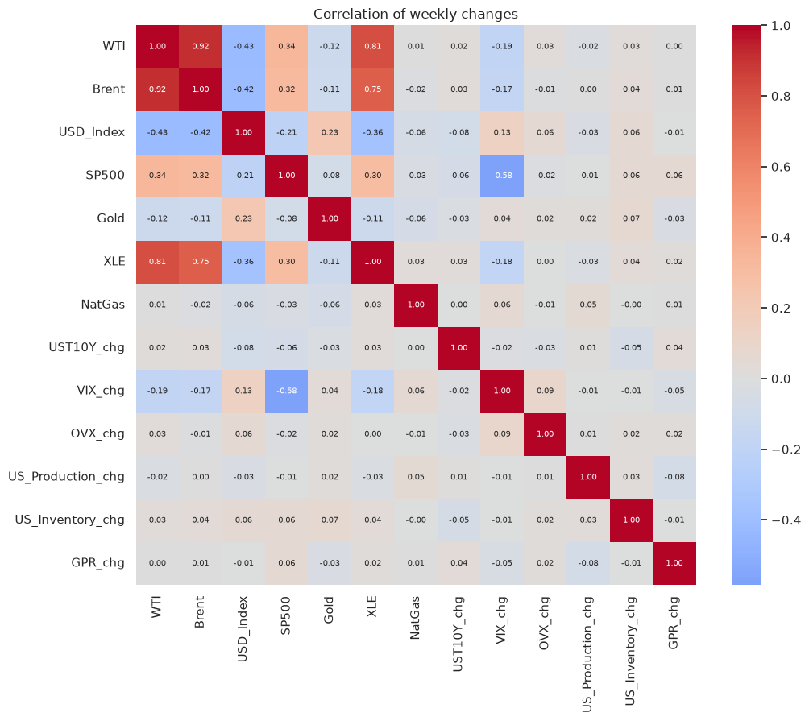

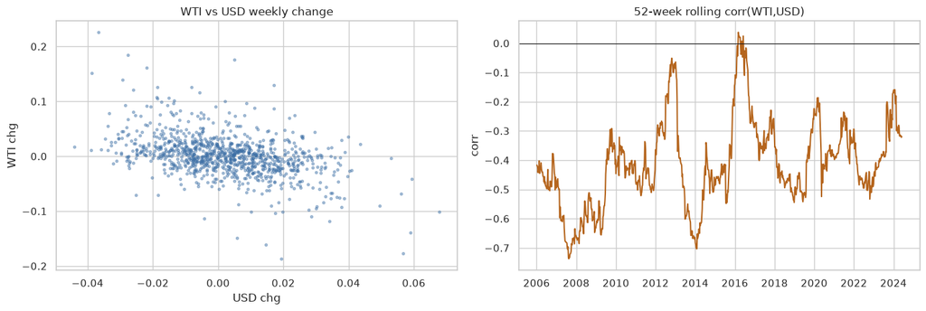

```python
rets=clean_df[["WTI","Brent","USD_Index","SP500","Gold","XLE","NatGas"]].pct_change().dropna()
lvl =clean_df[["UST10Y","VIX","OVX","US_Production","US_Inventory","GPR"]].pct_change().add_suffix("_chg")
corr=pd.concat([rets,lvl],axis=1,sort=False).dropna().corr()
plt.figure(figsize=(11,9))
sns.heatmap(corr,annot=True,fmt=".2f",cmap="coolwarm",center=0,square=True,annot_kws={"size":7})
plt.title("Correlation of weekly changes"); plt.tight_layout(); plt.show()

fig,ax=plt.subplots(1,2,figsize=(14,4.8))
ax[0].scatter(clean_df.USD_Index.pct_change(),clean_df.WTI.pct_change(),s=7,alpha=.4,color="#3b6ea5")
ax[0].set(title="WTI vs USD weekly change",xlabel="USD chg",ylabel="WTI chg")
roll=clean_df.WTI.pct_change().rolling(52).corr(clean_df.USD_Index.pct_change())
ax[1].plot(roll.index,roll,color="#b5651d"); ax[1].axhline(0,color="k",lw=.8)
ax[1].set(title="52-week rolling corr(WTI,USD)",ylabel="corr")
plt.tight_layout(); plt.show()
```

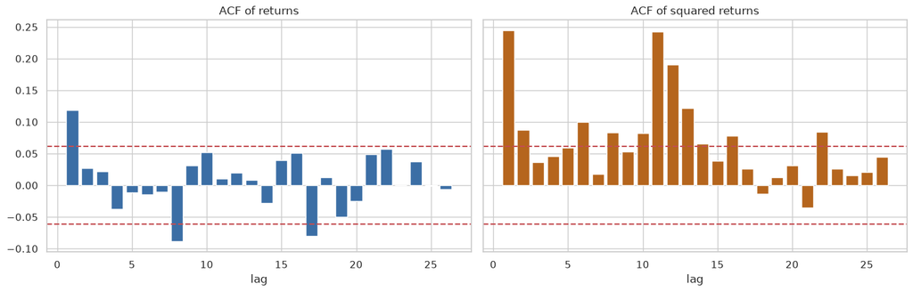

```python
lags=26; ac_r=acf(r,nlags=lags,fft=True)[1:]; ac_r2=acf(r**2,nlags=lags,fft=True)[1:]
ci=1.96/np.sqrt(len(r))
fig,ax=plt.subplots(1,2,figsize=(14,4.6),sharey=True)
ax[0].bar(range(1,lags+1),ac_r,color="#3b6ea5"); ax[0].axhline(ci,color="r",ls="--"); ax[0].axhline(-ci,color="r",ls="--")
ax[0].set(title="ACF of returns",xlabel="lag")
ax[1].bar(range(1,lags+1),ac_r2,color="#b5651d"); ax[1].axhline(ci,color="r",ls="--"); ax[1].axhline(-ci,color="r",ls="--")
ax[1].set(title="ACF of squared returns",xlabel="lag")
plt.tight_layout(); plt.show()
```